# Chapter 2 Practice Problems

Steven Pollack

13/08/2020

**2E1.** Which of the expressions below correspond to the statement: *the probability of rain on Monday?*

1. Pr(rain)
2. Pr(rain|Monday)
3. Pr(Monday|rain)
4. Pr(rain, Monday)/ Pr(Monday)

**Solution:** (2), obviously. (4):
$$\frac{Pr(\text{Monday, rain})}{Pr(\text{Monday})} = Pr(\text{rain|Monday})$$
which is (2), so (2) and (4).

**2E2.** Which of the following statements corresponds to the expression: *Pr(Monday|rain)?*

1. The probability of rain on Monday.
2. The probability of rain, given that it is Monday.
3. The probability that it is Monday, given that it is raining.
4. The probability that it is Monday and that it is raining.

**Solution:** going through each:

1. $PR(\text{rain|Monday})$
2. $Pr(\text{rain|Monday})$
3. $Pr(\text{Monday|rain})$
4. $Pr(\text{Monday, rain})$

so, only #3. is correct.

**2E3.** Which of the expressions below correspond to the statement: *the probability that it is Monday, given that it is raining?*

1. Pr(Monday|rain)
2. Pr(rain|Monday)
3. Pr(rain|Monday) Pr(Monday)
4. Pr(rain|Monday) Pr(Monday)/ Pr(rain)
5. Pr(Monday|rain) Pr(rain)/ Pr(Monday)

**Solution:** let’s translate each:

1. *the probability that it is Monday, given it is raining.* **(correct)**
2. *the probability that it is raining, given that it is Monday.*
3. equal to $Pr(\text{rain, Monday})$ which is *the probability that it is raining and it is Monday.*
4. using Bayes rule, this is equal to $Pr(\text{Monday|rain})$ which is option #1 and hence **correct**.
5. using bayes rule, this is equal to option #2.

Thus, options #1 and #4.

**2E4, solution:** see solution manual. The answer is more philosophical than you’d guess. The 70% chance is less a statement about the physical process and more an indictment of our ignorance. *“The physics of the globe toss are deterministic, not ‘random.’”*. But since we don’t really understand the physics of the globe toss, the process seems ‘random’.

**2M1, solution:** below is code to process data of the form `"W,W,L"`. It’ll do a grid approximation of the beta-binomial model using “W” as success and “L” and failure.

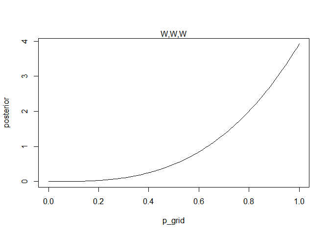

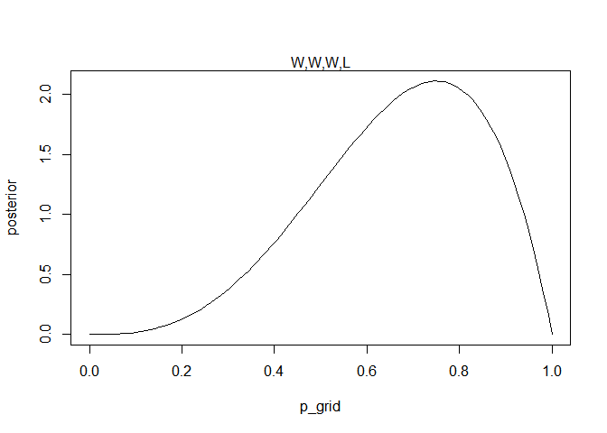

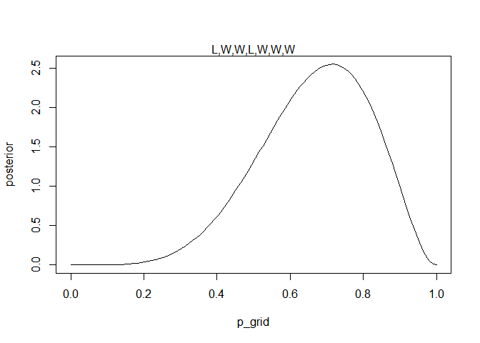

```r
# create function to do grid approx
grid_approx <- function(data, prior=NA, grid_length=100) {
  d <- strsplit(data, ",")[[1]]
  n_W <- sum(d == "W")
  n_trials <- length(d)


  # define grid
  p_grid <- seq(from=0, to=1, length.out=grid_length)
  dx <- diff(p_grid)

  if (is.na(prior)) {
    # define prior (uniform)
    prior <- rep(1, grid_length)
  } else { # assume that prior is a function and
    # normalize it
    p <- sapply(p_grid, prior)
    c <- 1/sum(p*dx) # this is our normalization constant
    prior <- p/c
  }

  # compute likelihood across the grid
  likelihood <- dbinom(n_W, size=n_trials, prob=p_grid)

  # normalize
  posterior <- (likelihood*prior)/sum(likelihood*prior*dx)

  # plot
  plot(p_grid, posterior, type="l")
  mtext(data)
}
```

**2M2. solution** The step-function prior looks like

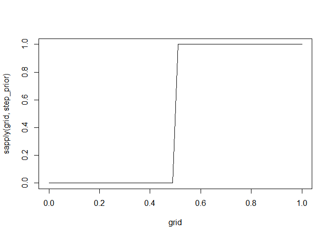

```r
grid <- seq(from=0, to=1, length.out=50)
step_prior <- function(x) ifelse(x < 0.5, 0, 1)
plot(grid, sapply(grid, step_prior), type="l")
```

So:

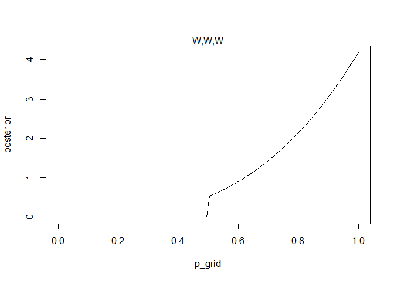

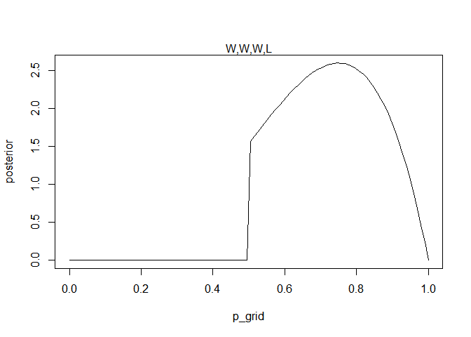

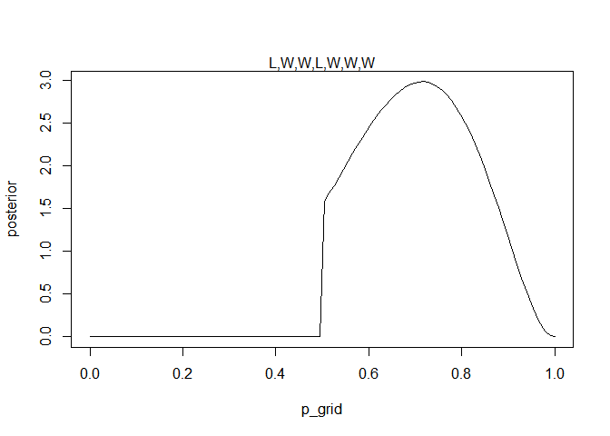

**2M3. Solution:** This is just straight Bayes Rule:
$$\begin{align}
P(E|L) &= \frac{P(L|E) \cdot P(E)}{P(L)} \\
&= \frac{P(L|E) \cdot P(E)}{P(L|E)\cdot P(E) + P(L|M) \cdot P(M)} \\
&=\frac{0.3 \cdot 0.5}{0.3\cdot0.5 + 1.0\cdot0.5} \\
&\approx 0.2308
\end{align}$$

**2M4. Solution:** If you use the garden of forking data approach, you’ll see there are 3/6 ways for a drawn card to reveal a black front. From those 3 ways, you have another 2/3 ways that the other side of that card can be black. Hence, $P(b=B|f=B) = 2/3$. However, you can work it out another way:
$$\begin{align}
P(b=B | f=B) &= \frac{P(f=B, b=B)}{P(f=B)} \\
&= \frac{1/3}{3/6} \\
&= \frac{2}{3}
\end{align}$$

since you know that there are only 1/3 cards that have both front and back sides that are black, and the chance that a randomly drawn front side is black is 3/6.

**2M5. Solution:** again $P(f=B, b=B) = 2/4 = 1/2$ and now $P(f=B)=5/8$ since there are 8 ways any of the four cards could be drawn, and 5 of them yield black fronts. Thus,
$$P(b=B|f=B) = \frac{1/2}{5/8} = \frac{4}{5}$$

**2M6. Solution:** using the counting method:

| card | # of cards | # of black sides | # of ways to produce a black side | frequency |
| --- | --- | --- | --- | --- |
| B/B | 1 | 2 | 2 | 50% |
| B/W | 2 | 1 | 2 | 50% |
| W/W | 3 | 0 | 0 | 0 |

**2M7. Solution:**

| C<sub>1</sub> | C<sub>2</sub> | # of ways to to see (B,W) | frequency |  |
| --- | --- | --- | --- | --- |
| B/B | B/W | 2*1 | 2/8 |  |
| B/B | W/W | 2*2 | 4/8 |  |
| B/W | B/B | 1*0 | 0 |  |
| B/W | W/W | 1*2 | 2/8 |  |
| W/W | B/B | 0*0 | 0 |  |
| W/W | B/W | 0*1 | 0 |  |

So, $P(C_1 = B/B) = 2/8+4/8 = 3/4$.

**2H1. Solution:** We need to calculate $P(b_2=T|b_1=T)$:
$$P(b_2=T|b_1=T) = \frac{P(b_1=T, b_2=T)}{P(b_1=T)}$$
However, the denominator is easier to calculate and we’ll do that straight from the problem description:
$$\begin{align}
P(T) &= P(T|A)P(A) + P(T|B)P(B) \\
&= 0.1(0.5) + 0.2(0.5) \\
&= 0.15
\end{align}$$
Furthermore, if we assume that each birth is independent, then $P(T,T|A)=P(T|A)P(T|A)$, for example. Hence:
$$\begin{align}
P(T,T) &= P(T,T|A)P(A) + P(T,T)P(B) \\
&= P(T|A)^2 P(A) + P(T|B)^2 P(B) \\
&= \frac{1}{2}(0.1^2 + 0.2^2) \\
&= 0.025
\end{align}$$
Thus,
$$P(b_2=T|b_1=T) = \frac{P(b_1=T, b_2=T)}{P(b_1=T)} = \frac{0.025}{0.15} = \frac{1}{6} \approx 0.17$$

**2H2. Solution:** Compute the probability that the panda in question is from species A, assuming the first birth was twins.

$$\begin{align}
P(A|T) = \frac{P(T|A)P(A)}{P(T)} = \frac{0.1 \times 0.5 }{0.15} = \frac{1}{3}
\end{align}$$

**2H3. Solution:** Given the second birth is a singleton, compute the posterior probability that this is from species A:
$$\begin{align}
P(A|T,-T) = \frac{P(A,T, -T)}{P(T, -T)}
\end{align}$$
Now, assuming that the births are independent, we’d then calculate
$$\begin{align}
P(A, T, -T) &= P(T, -T|A) P(A)\\
&= P(T|A)P(-T|A) P(A)\\
&= 0.1 \times 0.9 \times 0.5 \\
&= 0.045
\end{align}$$
The likelihood in the denominator follows the same pattern as in 2H1:
$$\begin{align}
P(T,-T) &= P(T,-T|A)P(A) + P(T,-T)P(B) \\
&= P(T|A)P(-T|A) P(A) + P(T|B) P(-T|B) P(B) \\
&= \frac{1}{2}(0.1\times 0.9 + 0.2\times 0.8) \\
&= 0.125
\end{align}$$
Putting it all together:
$$\begin{align}
P(A|T,-T) = \frac{P(A,T, -T)}{P(T, -T)} = \frac{0.045}{0.125} = 0.36
\end{align}$$
Alternatively, we could carry information from the first birth over as our new and just focus on the second birth:
$$P(A^*|-T) = \frac{P(-T|A^*)P(A^*)}{P(-T)}$$
where $A^*$ is the event that the panda is from species A and they’ve already had a pair of twins. In this way, we calculated $P(A^*)$ in 2H2 as 1/3 and $P(-T|A^*) = P(-T|A) = 0.9$ since we assume that the birth outcomes aren’t correlated. So:
$$P(A^*|-T) = \frac{P(-T|A^*)P(A^*)}{P(-T)} = \frac{0.9\times \frac{1}{3}}{0.9\times \frac{1}{3} + 0.8\times \frac{2}{3}}
= 0.36$$

**2H4. Solution:**

Part 1: compute $P(s=A|t=A)$.
$$\begin{align}
P(s=A|t=A) &= \frac{P(t=A|s=A)P(s=A)}{P(t=A)} \\
&= \frac{P(t=A|s=A)P(s=A)}{P(t=A|s=A)P(s=A) + P(t=A|s=B)P(s=B)} \\
&= \frac{0.8 \times 0.5 }{0.8\times0.5 + 0.35\times0.5} \\
&\approx 0.696
\end{align}$$
Part 2: compute $P(s=A|t=A, b_1=T, b_2=-T)$. We’ll use the computation in the question 2H3 as our prior in Bayes formula:
$$\begin{align}
P(s=A|t=A, T, -T) &= \frac{P(s=A, t=A, T, -T)}{P(t=A, T, -T)} \\
&= \frac{P(t=A|s=A,T,-T)P(s=A, T, -T)}{P(t=A,T,-T)} \\
&= \frac{P(t=A|A,T,-T) P(s=A,T,-T)/P(T,-T)}{P(t=A,T,-T)/P(T,-T)} \\
&= \frac{P(t=A|A,T,-T)P(s=A|T,-T)}{P(t=A|T,-T)}
\end{align}$$

Note that the test’s specificity isn’t affected by birth data so $P(t=A|s=A, T, -T) = P(t=A|s=A) = 0.8$. Furthermore, we calculated $P(s=A|T,-T) = 0.36$. So, it remains to figure out the denominator. Using the definition of conditional probability, it follows that
$$\begin{align}
P(t=A|T,-T) &= P(t=A|s=A, T,-T)P(s=A|T,-T) + P(t=A|s=b,T,-T) P(s=B|T,-T) \\
&= 0.8\times 0.36 + 0.35\times 0.64 \\
&=0.512
\end{align}$$

So, putting it all together:

$$\begin{align}
P(s=A|t=A, T, -T) &= \frac{0.8\times0.36}{0.512} \\
&= 0.5625
\end{align}$$